# Course evaluations and simple linear regression

Le Nguyen

# Introduction

This is adapted from Lab 6 in Duke’s Introduction to Data Science course.

We will analyze what goes into course evaluations and how certain variables effect the overall score.

To get started, load packages `tidyverse` and `broom`. Install any packages with code `install.packages("package_name")`.

```r
library(tidyverse)
library(broom)
```

# Data

The data were gathered from end of semester student evaluations for a large sample of professors from the University of Texas at Austin. In addition, six students rated the professors’ physical appearance. Each row in `evals` contains a different course and the columns represent variables about the courses and professors.

Use `read_csv()` to read in the data and save it as an object named `evals`. The data is available on D2L.

```r
evals <- read_csv("evals-mod.csv")
glimpse(evals)
```

```
Rows: 463
Columns: 18
$ score         <dbl> 4.7, 4.1, 3.9, 4.8, 4.6, 4.3, 2.8, 4.1, 3.4, 4.5, 3.8, …
$ rank          <chr> "tenure track", "tenure track", "tenure track", "tenure…
$ ethnicity     <chr> "minority", "minority", "minority", "minority", "not mi…
$ gender        <chr> "female", "female", "female", "female", "male", "male",…
$ language      <chr> "english", "english", "english", "english", "english", …
$ age           <dbl> 36, 36, 36, 36, 59, 59, 59, 51, 51, 40, 40, 40, 40, 40,…
$ cls_perc_eval <dbl> 55.81395, 68.80000, 60.80000, 62.60163, 85.00000, 87.50…
$ cls_did_eval  <dbl> 24, 86, 76, 77, 17, 35, 39, 55, 111, 40, 24, 24, 17, 14…
$ cls_students  <dbl> 43, 125, 125, 123, 20, 40, 44, 55, 195, 46, 27, 25, 20,…
$ cls_level     <chr> "upper", "upper", "upper", "upper", "upper", "upper", "…
$ cls_profs     <chr> "single", "single", "single", "single", "multiple", "mu…
$ cls_credits   <chr> "multi credit", "multi credit", "multi credit", "multi …
$ bty_f1lower   <dbl> 5, 5, 5, 5, 4, 4, 4, 5, 5, 2, 2, 2, 2, 2, 2, 2, 2, 7, 7…
$ bty_f1upper   <dbl> 7, 7, 7, 7, 4, 4, 4, 2, 2, 5, 5, 5, 5, 5, 5, 5, 5, 9, 9…
$ bty_f2upper   <dbl> 6, 6, 6, 6, 2, 2, 2, 5, 5, 4, 4, 4, 4, 4, 4, 4, 4, 9, 9…
$ bty_m1lower   <dbl> 2, 2, 2, 2, 2, 2, 2, 2, 2, 3, 3, 3, 3, 3, 3, 3, 3, 7, 7…
$ bty_m1upper   <dbl> 4, 4, 4, 4, 3, 3, 3, 3, 3, 3, 3, 3, 3, 3, 3, 3, 3, 6, 6…
$ bty_m2upper   <dbl> 6, 6, 6, 6, 3, 3, 3, 3, 3, 2, 2, 2, 2, 2, 2, 2, 2, 6, 6…
```

```r
attach(evals)
levels(as.factor(cls_profs))
```

```
[1] "multiple" "single"
```

## Data dictionary

| **Variable** | **Description** |
| --- | --- |
| score | Average professor evaluation score: (1) very unsatisfactory - (5) excellent |
| rank | Rank of professor: teaching, tenure track, tenure |
| ethnicity | Ethnicity of professor: not minority, minority |
| gender | Gender of professor: female, male |
| language | Language of school where professor received education: english or non-english |
| age | Age of professor |
| cls_perc_eval | Percent of students in class who completed evaluation |
| cls_did_eval | Number of students in class who completed evaluation |
| cls_students | Total number of students in class |
| cls_level | Class level: lower, upper |
| cls_profs | Number of professors teaching sections in course in sample: single, multiple |
| cls_credits | Number of credits of class: one credit (lab, PE, etc.), multi credit |
| bty_f1lower | Beauty rating of professor from lower level female: (1) lowest - (10) highest |
| bty_f1upper | Beauty rating of professor from upper level female: (1) lowest - (10) highest |
| bty_f2upper | Beauty rating of professor from upper level female: (1) lowest - (10) highest |
| bty_m1lower | Beauty rating of professor from lower level male: (1) lowest - (10) highest |
| bty_m1upper | Beauty rating of professor from upper level male: (1) lowest - (10) highest |
| bty_m2upper | Beauty rating of professor from upper level male: (1) lowest - (10) highest |

# Exploratory data analysis

#### Task 1

Create a scatter plot between `score` and a quantitative variable. Comment on the relationship. What do you think the correlation is between the variables?

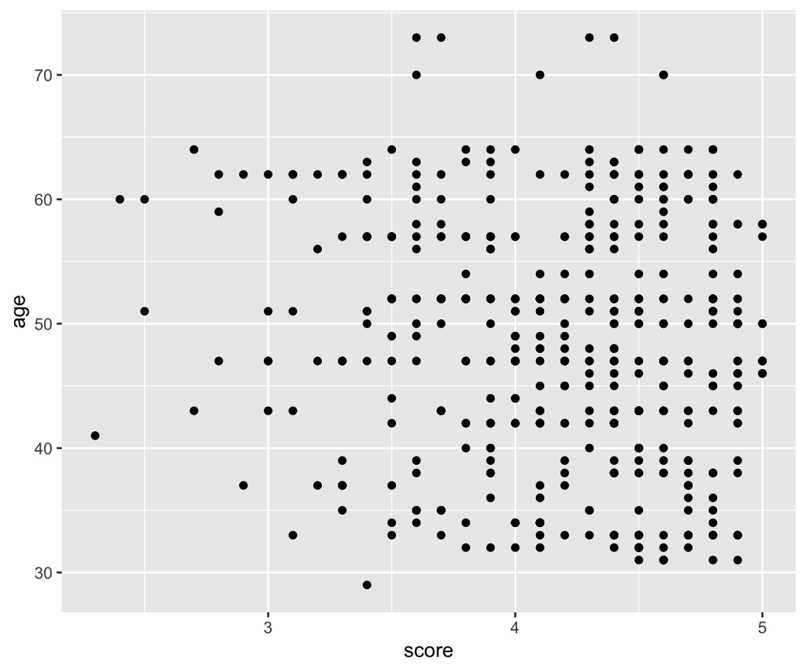

```r
library(ggplot2)

ggplot(evals, aes(score, age)) + geom_point()
```

```r
#No correlation, the values look pretty evenly distributed.
```

#### Task 2

Create a scatter plot between `score` and a categorical variable. Comment on the relationship. Add `geom_jitter()` to your plot. What do you notice about the variability in score between different levels?

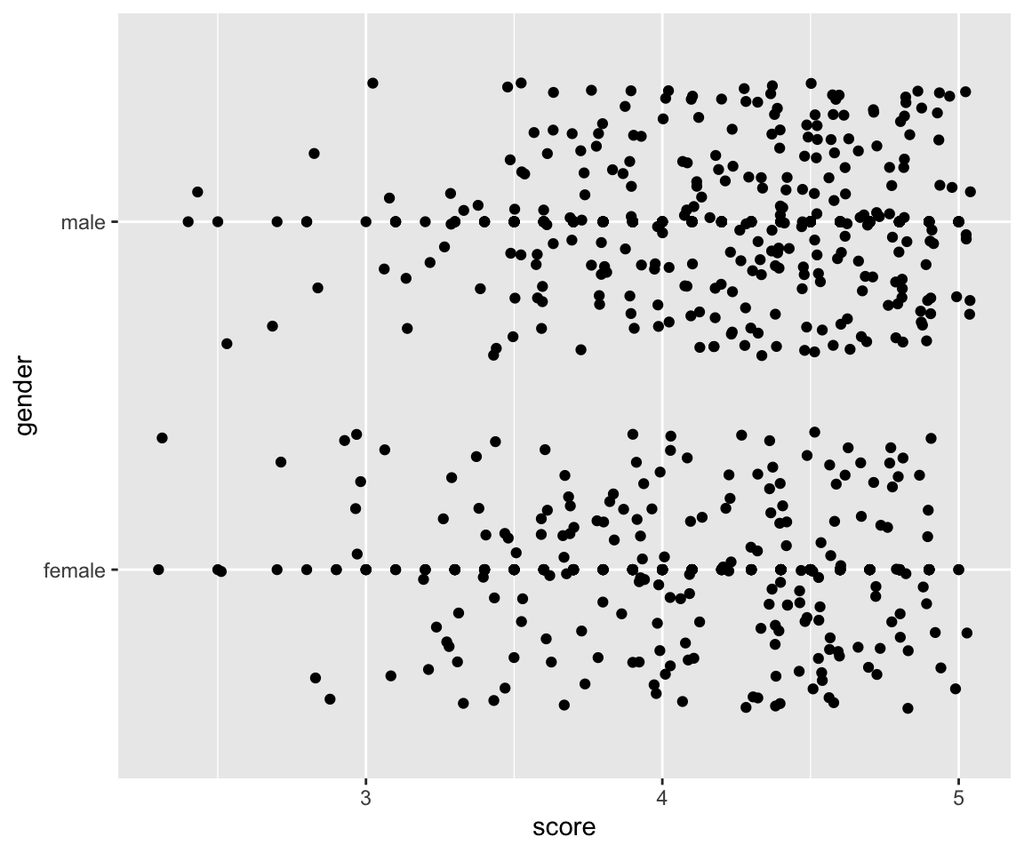

```r
ggplot(evals, aes(score, gender)) + geom_point() + geom_jitter()
```

```r
#The score seems equally variable across genders
```

#### Task 3

Create a variable named `avg_bty`. This is the average attractiveness from the six student scores for each professor. Add this variable to `evals`. *Hint*: `rowwise()` then `mutate()` then `ungroup()`

```r
evals = evals %>%
  rowwise() %>%
  mutate(avg_bty = mean(c_across(bty_f1lower:bty_m2upper)))
```

#### Task 4

Create a scatter plot between `score` and `avg_bty`. Comment on the relationship. What do you think the correlation is between the variables?

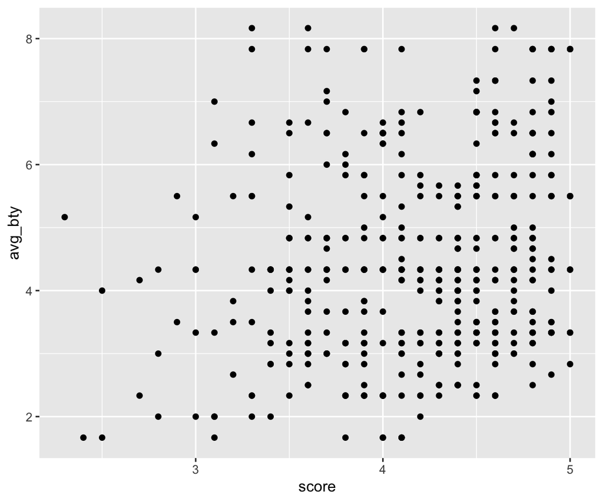

```r
ggplot(evals, aes(score, avg_bty)) + geom_point()
```

```r
#Slight positive correlation between the two variables.
```

#### Task 5

Modify your plot from Task 4. Add a layer with `geom_jitter()`. Comment on the relationship.

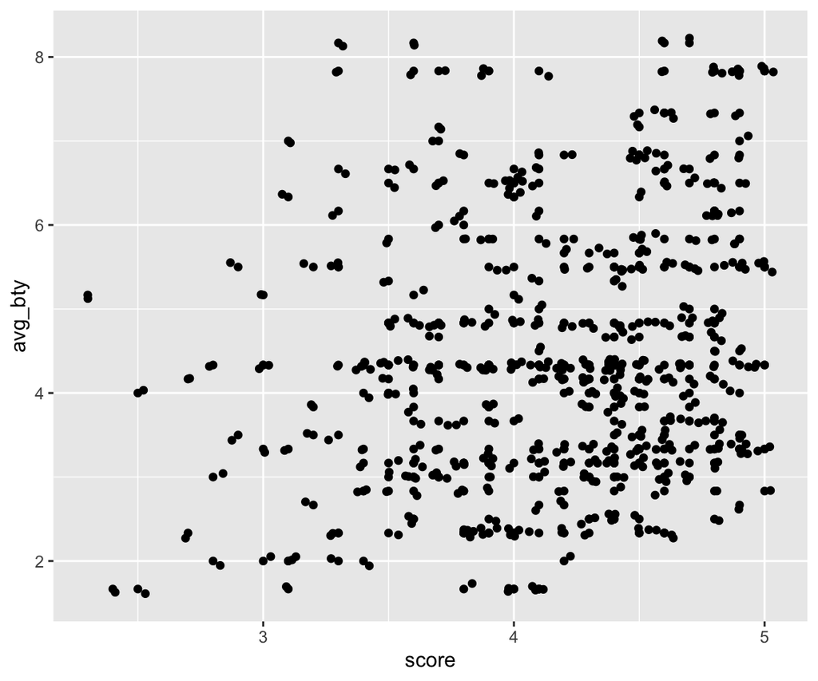

```r
ggplot(evals, aes(score, avg_bty)) + geom_point() + geom_jitter()
```

```r
#The positive corrolation between the variables is more apparent now.
```